# Praca Domowa 3

Krzysztof Kosz

# **1. Wstęp**

Przeprowadziłem badanie czytelności wykresów, porównując dwa wykresy kołowe oraz wykres słupkowy. Do wszystkich wykresów zostały wykorzystane różne permutacje tego samego zbioru danych, aby nie można było się sugerować wcześniejszymi odpowiedziami. Początkowo miałem się skupić tylko na jednym wykresie kołowym oraz słupkowym, jednak tworząc wykres kołowy uznałem, że ciężej się go czyta gdy wartości są pomieszane a łatwiej gdy ułożone są one rosnąco. Postanowiłem to również sprawdzić w badaniu, dlatego uwzględniłem dwa wykresy kołowe. Ankieta została przeprowadzona wśród 15 osób. Zostały im zadane 2 pytania które powinny dać tą samą odpowiedź na każdym wykresie (uwzględniając permutacje zbioru danych oraz to, że czasem pytanie było o uporządkowanie malejąco, a czasem rosnące) oraz 1 pytanie odnośnie subiektywnego odczucia na temat czytelności wykresów.

# **2. Wykresy oraz ankieta**

Poniżej zaprezentowałem wykresy wraz z zapytaniami, które otrzymali ankietowani. Przy każdym wykresie zaprezentowałem również przypisanie danych w danym zbiorze danych.

## Wykres kołowy nr 1

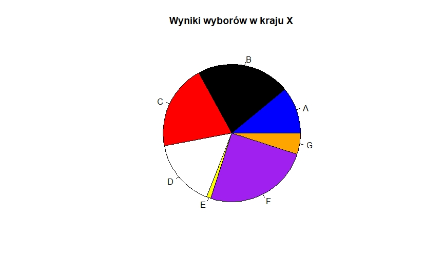

Zbiór danych:

A=11, B=22, C=20, D=16, E=1, F=25, G=5

Zadane pytania (polecenia):

1. Proszę uporządkować kandydatów w kolejności **malejącej** względem procentowej ilości głosów.
2. Jaki procent głosów uzyskał kandydat **B**?

## Wykres kołowy nr 2

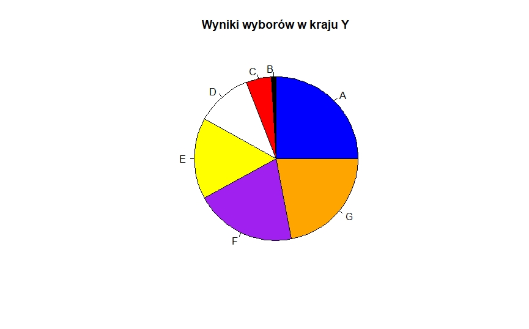

Zbiór danych:

A=25, B=1, C=5, D=11, E=16, F=20, G=22

Zadane pytania (polecenia):

1. Proszę uporządkować kandydatów w kolejności **malejącej** względem procentowej ilości głosów.
2. Jaki procent głosów uzyskał kandydat **G**?

## Wykres słupkowy

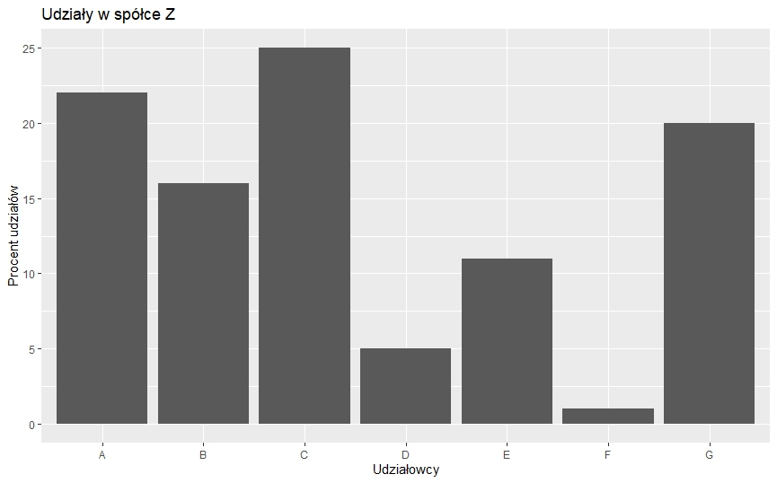

Zbiór danych:

A=22, B=16, C=25, D=5, E=11, F=1, G=20

Zadane pytania (polecenia):

1. Proszę uporządkować udziałowców w kolejności **rosnącej** względem procentowej ilości udziałów.
2. Jaki procent udziałów stanowią te udziałowca **A**?

## Pytanie ogólne

Pytanie ogólne brzmiało:

Który wykres jest najłatwiejszy w odczycie?

# **3. Wyniki**

### **Pytanie nr 1**

Uznałem, że najłatwiej będzie porównać odpowiedzi do pierwszego pytania przyznając punkt za każde poprawne wystąpienie w szeregu danej wartości. Porównuję wyniki pokazując procent ilości punktów “uzyskanych przez wykres”.

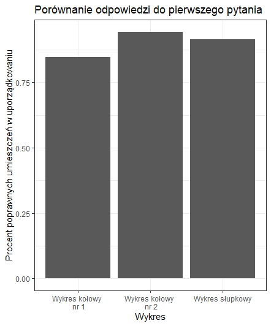

### **Pytanie nr 2**

Poniżej w tabelce przedstawiam wyniki badania z obliczoną wartością średnią oszacowań, błędem względnym i bezwzględnym oraz odchyleniem standardowym.

|  | Wykres kołowy nr 1 | Wykres kołowy nr 2 | Wykres słupkowy |
| --- | --- | --- | --- |
| Prawidłowa wartość do oszacowania | 22 | 22 | 22 |
| Średnia wartość oszacowania | 21,36 | 21,63 | 22,6 |
| Średni błąd bezwzględny | 1,66 | 1,26 | 0,6 |
| Średni błąd względny | 7,56% | 5,74% | 2,73% |
| Odchylenie standardowe | 1,66 | 1,37 | 0,87 |

### **Pytanie ogólne**

Nie ma potrzeby robienia wielkiej analizy odnośnie ostatniego pytania bo **100%** odpowiedzi wskazało wykres słupkowy jako najłatwiejszy w odczycie.

# **4. Wnioski**

Badanie przyniosło ciekawe wyniki:

Jeśli chodzi o odczytywanie danych z wykresóW to ewidentnie najłatwiej się je odczytuje z wykresu słupkowego, gdzie wartość błędu względnego i bezwzględnego jest najmniejsze a po odchyleniu standardowym widać, iż rozrzut odpowiedzi jest najmniejszy. Na kolejnych miejscach uplasowały się wykres kołowy “uporządkowany” oraz “nieuporządkowany”.

Ostatnie pytanie daje nam również pogląd na odczucie badanych, że wykres słupkowy jets tym najłatwiejszym w odczycie.